# Peer Assessment II

# 1 Background

As a statistical consultant working for a real estate investment firm, your task is to develop a model to predict the selling price of a given home in Ames, Iowa. Your employer hopes to use this information to help assess whether the asking price of a house is higher or lower than the true value of the house. If the home is undervalued, it may be a good investment for the firm.

# 2 Training Data and relevant packages

In order to better assess the quality of the model you will produce, the data have been randomly divided into three separate pieces: a training data set, a testing data set, and a validation data set. For now we will load the training data set, the others will be loaded and used later.

```r
load("ames_train.Rdata")
load("ames_test.Rdata")
load("ames_validation.Rdata")
```

Use the code block below to load any necessary packages

```r
library('plyr')         # data manipulation
library('ggplot2')      # library to create plots
library('dplyr')        # data manipulation
library('knitr')        # required to apply knitr options
library('statsr')       # staistics functions

library('GGally')       # library to create plots
library('gridExtra')    # arrange plots
library('BAS')          # Bayesian statistics functions
library('labeling')     # dependency package to ggplot

library('MASS')         # Support Functions
library('car')          # Companion to Applied Regression

library('corrplot')     # correlation plot
library('RColorBrewer') # Color scheme

source('helper.R')      # support functions used in the analysis - See Appendix

# apply general knitr options
knitr::opts_chunk$set(comment=NA, fig.align='center')
```

```r
data.train <- ames_train
data.test <- ames_test
data.validation <- ames_validation
rm(ames_test, ames_train, ames_validation)
```

## 2.1 Part 1 - Exploratory Data Analysis (EDA)

**Summarize Missing values**

We initially start verifying the missing values in our data set. This is just an initial step to define, which feature needs maintenance.

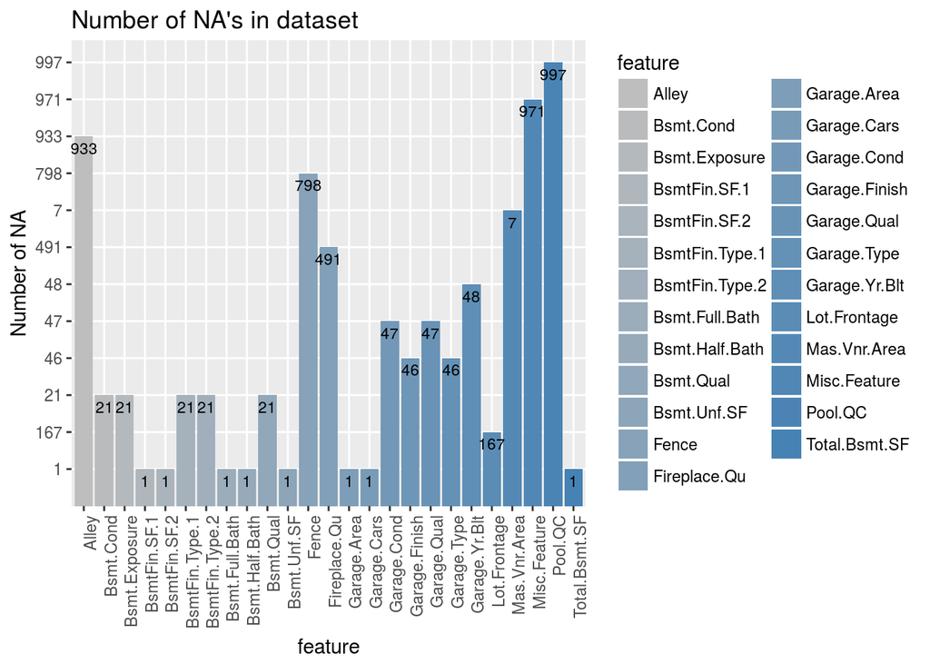

```r
# check which features contain NA values
CheckNA(data.train, 2)
```

**Strategy for missing values**

Handling missing values is an important part of the data cleaning. The chosen approach is not meant to be a highly sophisticated approach to fill the missing values, but will fulfil it’s duty. The codebook reveals that for multiple features `NA` value have been applied, if an item doesn’t exist (e.g. Garage.Cars -> NA means no garage). The original dataset also contains empty values. We’ll transform the empty values into `NA's`. In case of a numerical feature we apply a `0` value, for categorical features (e.g. `poor`, `fair`, `typical/average`, `good` and `excellent`), we’ll map numeric values (e.g. `0 - 5`) to their corresponding categoric values (including `0` for none) and combine those with our dataset. But there are also categorical features where an `NA` placeholder will get a value assigned. The assigned value has been evaluated based on the majority of occurrences. Find the list below.

**Categorical features containing an `NA` value will be set to `none`, and mapped to a defined value**

Feature `Paved.Drive` set to **1** parameter `Grvl` Feature `Street` set to **1** parameter `Grvl` Feature `Lot.Config` set to **1** parameter `Inside` Feature `MS.Zoning` set to **1** parameter `A(all)` Feature `Land.Slope` set to **1** parameter `Gtl` Feature `Lot.Shape` set to **1** parameter `Reg` Feature `Land.Contour` set to **1** parameter `Lvl` Feature `Sale.Condition` set to **1** parameter `Normal` Feature `Sale.Type` set to **10** parameter `WD` Feature `Electrical` set to **5** parameter `SBrkr` Feature `Heating` set to **2** parameter `GasA` Feature `Foundation` set to **3** parameter `Pconc` Feature `Exterior.1st` set to **15** parameter `VinylSD` Feature `Exterior.2nd` set to **15** parameter `VinylSD` Feature `Condition.1 / Condition.2` set to **3** parameter `Norm` Feature `Roof.style` set to **2** parameter `Gable` Feature `Bldg.Type` set to **1** parameter `1Fam` Feature `House.Style` set to **1** parameter `1Story` Feature `Neighborhood` set to **1** parameter `Blmngtn`

**Categorical features containing an `NA` value will be set to `none` and mapped to a 0 value**

`Garage.type`, `Garage.Finish`, `Garage.Qual`, `Garage.Cond`, `Pool.QC`, `Fireplace.Qu`, `Fence`, `Misc.Feature`, `Alley`, `Bsmt.Qual`, `Bsmt.Cond`, `BsmtFin.Type.1`, `Bsmt.Exposure`, `BsmtFin.Type.2`

**Numerical features containing an `NA` will be set to 0**

`Garage.Cars`, `Garage.Area`, `Garage.Yr.Blt`, `BsmtFin.SF.1`, `BsmtFin.SF.2`, `Bsmt.Unf.SF`, `Total.Bsmt.SF`, `Bsmt.Full.Bath`, `Bsmt.Half.Bath`, `Mas.Vnr.Area`

```r
# Clean empty fields by adding an NA vaue. Then check for NA values and
# run filling in values for missing data

data.train <- cleanEmptyFields(data.train, NA)
data.train <- NaHandler(data.train)
CheckNA(data.train, 0)             # This check should reveil no NA values
data.train <- recode.features(data.train)

# NA value handling test data
data.test <- cleanEmptyFields(data.test, NA)
data.test <- NaHandler(data.test)
CheckNA(data.test, 0)              # This check should reveil no NA values
data.test <- recode.features(data.test)

# NA value handling validation data
data.validation <- cleanEmptyFields(data.validation, NA)
data.validation <- NaHandler(data.validation)
CheckNA(data.validation, 0)        # This check should reveil no NA values
data.validation <- recode.features(data.validation)
```

**Normalize Data set**

When dealing with values that lie in different ranges, it is common to normalize the data for better evaluation. Here, I used the min and max normalization approach.

```r
# Normalize training data set and store a original data set
df.train.normalized <- NormalizeDF(data.train, 'price')
df.train.normalized.org <- df.train.normalized

# Normalize test data set and store a original data set
df.test.normalized <- NormalizeDF(data.test, 'price')
df.test.normalized.org <- df.test.normalized

# Normalize validation data set and store a original data set
data.validation <- data.validation[complete.cases(data.validation), ]
df.validation.normalized <- NormalizeDF(data.validation, 'price')
df.validation.normalized.org <- df.validation.normalized
```

```r
# create working copies
df.train      <- data.train
df.test       <- data.test
df.validation <- data.validation

# final Clean Up
df.train      <- finalCleanUp(df.train)
df.test       <- finalCleanUp(df.test)
df.validation <- finalCleanUp(df.validation)

# create an original with and without outliners
df.train.Outliner   <- df.train
df.train.NoOutliner <- removeOutliners(df.train, c(428, 310))
```

**Correlation Matrix**

I’ve transformed all the categoric features with an ordinal scale into numeric columns. In order to determine the feature with the strongest relation towards price, we need to calculate the sample correlation coefficient between two variables.

We’re particularly interested in variables that show a strong relation to price, so we will focus primarily on features that have a coefficient > 0.5 or < -0.5.

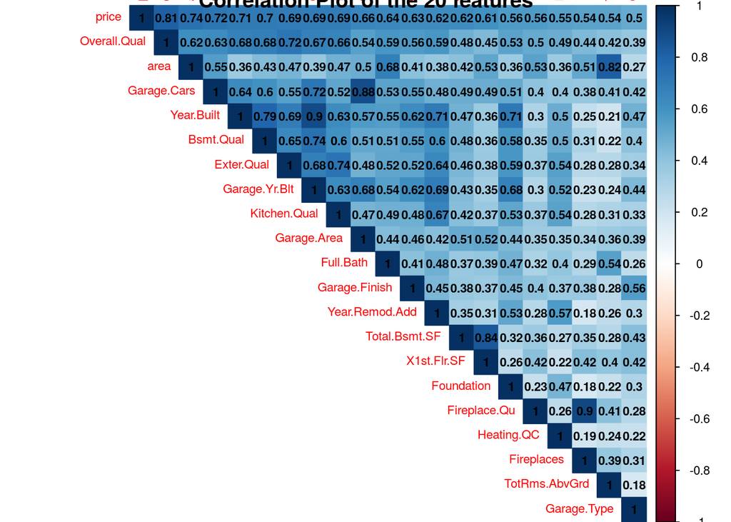

```r
correlations = cor(df.train, method = "s")

# only want the columns that show strong correlations with price
corr.price = as.matrix(sort(correlations[,'price'], decreasing = TRUE))

corr.idx = names(which(apply(corr.price, 1, function(x) (x > 0.5 | x < -0.5))))

corrplot(as.matrix(correlations[corr.idx,corr.idx]), type = 'upper', method='color',
         title = 'Correlation Plot of the 20 features',
         addCoef.col = 'black', tl.cex = .7,cl.cex = .7, number.cex=.7)
```

The correlation plot indicates the 20 features with the strongest effect on housing prices. I won’t go through all of them, but pick a few to comment on.

The features `Overall.Qual` and `area` show the strongest correlation. I reckon this makes sense, since the overall quality of a house must have an impact on the sales price. With `Garage.Cars`, `Year.Built` we ceratinly could expect those features to be important. Further we have the features with a quality aspect `Bsmt.Qual`, `Exter.Qual`, `Kitchen.Qual`, which I believe might be relevant. In general, all quality related features might have an impact.

I wouldn’t expect `Garage.Yr.Blt` to be an important feature, but let it be so. `YearBuilt`, `YearRemodAdd` a positive correlation of those features should be **NO** surprise to us. Newer homes will likely sell for higher prices then older ones.

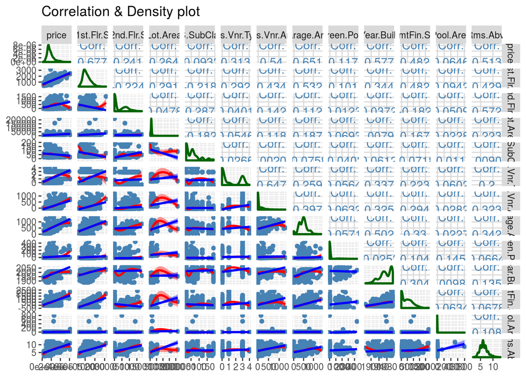

```r
df.train <- df.train %>% dplyr::select(price, X1st.Flr.SF,
                                       X2nd.Flr.SF, Lot.Area,
                                       MS.SubClass, Mas.Vnr.Type,
                                       Mas.Vnr.Area, Garage.Area,
                                       Screen.Porch, Year.Built,
                                       BsmtFin.SF.1, Pool.Area,
                                       TotRms.AbvGrd)


ggpairs(df.train,
          columns=1:13,
          upper = list(continuous = wrap('cor', size = 4, col = 'steelblue')),
          diag  = list(continuous = ggpairs_diag),
          lower = list(continuous = ggpairs_lower),
          title = 'Correlation & Density plot'
          )
```

This graph shows multiple information in a compact way. The main required information is to see the distribution of the given features, if we need to potentially transform the feature at a latter stage. It also shows the general correlation and some indication of outliners in a compact form. This plot is not meant to give detailed information. It is meant to be used to isolate some trends, potential problems etc. to give a hint where deeper investigation is required.

What we see here is, price is right skewed and not normal distributed, or that the feature `Mas.Vnr.Area` has some Outliners or high leverage points. Those findings will then require a deeper analysis.

```r
summary.Price <- df.train %>% dplyr::summarise(mean_Price   = mean(price),
                                    median_Price = median(price),
                                    sd_Price     = sd(price),
                                    min_Price    = min(price),
                                    max_Price    = max(price),
                                    IQR_Price    = IQR(price),
                                    total = n())
```

```r
kable(summary.Price[1:6], caption = 'Price table of Houses in Ames Iowa')
```

Price table of Houses in Ames Iowa

| mean_Price | median_Price | sd_Price | min_Price | max_Price | IQR_Price |
| --- | --- | --- | --- | --- | --- |
| 181190.1 | 159467 | 81909.79 | 12789 | 615000 | 83237.5 |

The table above just shows a summary of the sales prices of homes in Ames, Iowa.

## 2.2 Part 2 - Development and assessment of an initial model, following a semi-guided process of analysis

### 2.2.1 Section 2.1 An Initial Model

Running through the EDA and the codebook, I figured that the features, which are related to size, quality and condition would be major drivers for the sales price of a house. Therefore I came up with the following initial “intuitive” model.

Initial Model Selection **price ~ area + Overall.Qual + Overall.Cond + Kitchen.Qual + Bsmt.Qual + Exter.Qual + Year.Built + Garage.Area + Lot.Area + Fireplace.Qu**

Next we show a summary of our initial model.

```r
# 2.2.1 Initial Model selection
df.train <- df.train.Outliner

df.train <- df.train %>% dplyr::select(price, area, Overall.Qual,
                                                       Overall.Cond, Kitchen.Qual,
                                                       Year.Built, Bsmt.Qual,
                                                       Exter.Qual, Garage.Area,
                                                       Lot.Area, Fireplace.Qu)

initial.model  <- as.formula(price ~ area + Overall.Qual +
                               Overall.Cond + Year.Built +
                               Exter.Qual +  Bsmt.Qual +
                               Lot.Area + Kitchen.Qual +
                               Fireplace.Qu + Garage.Area)

initial.lm.model <- lm(initial.model , data = df.train)
summary(initial.lm.model)
```

```
Call:
lm(formula = initial.model, data = df.train)

Residuals:
    Min      1Q  Median      3Q     Max
-311027  -19699   -2799   16182  252027

Coefficients:
               Estimate Std. Error t value Pr(>|t|)
(Intercept)  -6.228e+05  1.137e+05  -5.475 5.53e-08 ***
area          4.179e+01  3.168e+00  13.192  < 2e-16 ***
Overall.Qual  1.236e+04  1.504e+03   8.215 6.62e-16 ***
Overall.Cond  4.899e+03  1.130e+03   4.336 1.60e-05 ***
Year.Built    2.251e+02  5.950e+01   3.784 0.000164 ***
Exter.Qual    2.273e+04  3.258e+03   6.978 5.49e-12 ***
Bsmt.Qual     8.767e+03  1.854e+03   4.729 2.58e-06 ***
Lot.Area      8.826e-01  1.192e-01   7.405 2.80e-13 ***
Kitchen.Qual  1.245e+04  2.675e+03   4.656 3.67e-06 ***
Fireplace.Qu  4.448e+03  7.659e+02   5.808 8.50e-09 ***
Garage.Area   5.695e+01  6.668e+00   8.541  < 2e-16 ***
---
Signif. codes:  0 '***' 0.001 '**' 0.01 '*' 0.05 '.' 0.1 ' ' 1

Residual standard error: 35170 on 989 degrees of freedom
Multiple R-squared:  0.8175,    Adjusted R-squared:  0.8157
F-statistic: 443.1 on 10 and 989 DF,  p-value: < 2.2e-16
```

Summary estimates should only be trusted if the conditions for the regression are reasonable. Having mentioned that, it will be relevant to validate the following aspects:

**Evaluate conditions for Regression**

There is a linear relationship between any numerical predictor variables and the response variable.

1-The residuals are nearly normal distributed 2-The residuals display constant variability 3-The residuals are independent

We first will examine whether the numerical variables included in the model, are linearly related to the response variable `price` by examining the distribution of the residuals.

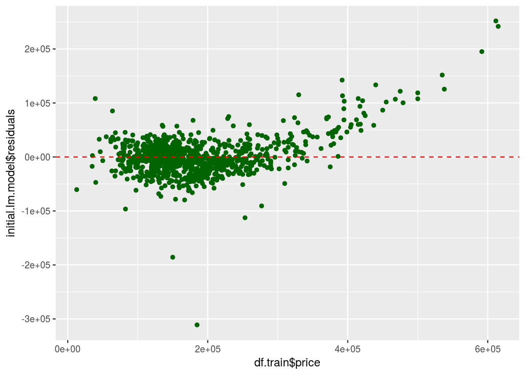

```r
ggplot(data = NULL, aes(x = df.train$price, y = initial.lm.model$residuals)) +
  geom_point(col = 'darkgreen') +
  geom_hline(yintercept = 0, linetype = 'dashed', color = 'red')
```

The residuals are scattered randomly around 0 in most cases except for the ones in the higher price segment. In general the residuals exhibit “heteroscedasticity”, meaning that the residuals get larger as the prediction moves from small to large. This is something we need to keep in mind. Next, we check whether the residuals display a nearly normal distribution centred around 0.

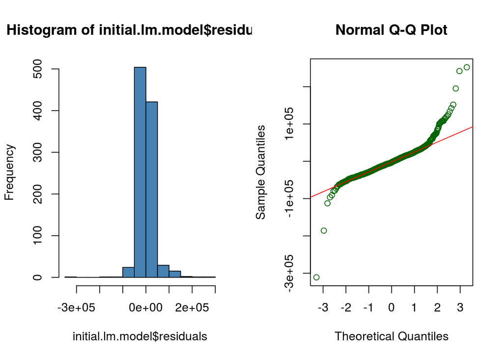

```r
par(mfrow = c(1,2))
hist(initial.lm.model$residuals, col = 'steelblue')
qqnorm(initial.lm.model$residuals, col = 'darkgreen')
qqline(initial.lm.model$residuals, col = 'red')
```

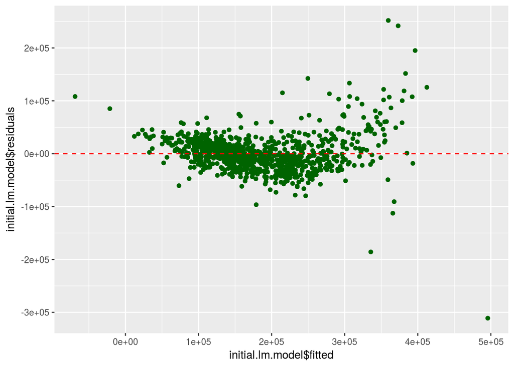

```r
par(mfrow = c(1,2))
ggplot(data = NULL, aes(x = initial.lm.model$fitted, y = initial.lm.model$residuals)) +
  geom_point(col = 'darkgreen') +
  geom_hline(yintercept = 0, linetype = 'dashed', color = 'red')
```

```r
anova(initial.lm.model)
```

```
Analysis of Variance Table

Response: price
              Df     Sum Sq    Mean Sq   F value    Pr(>F)
area           1 3.4048e+12 3.4048e+12 2753.3952 < 2.2e-16 ***
Overall.Qual   1 1.4310e+12 1.4310e+12 1157.2275 < 2.2e-16 ***
Overall.Cond   1 7.7238e+08 7.7238e+08    0.6246    0.4295
Year.Built     1 1.8496e+11 1.8496e+11  149.5683 < 2.2e-16 ***
Exter.Qual     1 1.4316e+11 1.4316e+11  115.7720 < 2.2e-16 ***
Bsmt.Qual      1 4.4619e+10 4.4619e+10   36.0825 2.655e-09 ***
Lot.Area       1 9.7010e+10 9.7010e+10   78.4495 < 2.2e-16 ***
Kitchen.Qual   1 3.5327e+10 3.5327e+10   28.5680 1.123e-07 ***
Fireplace.Qu   1 4.7596e+10 4.7596e+10   38.4899 8.080e-10 ***
Garage.Area    1 9.0206e+10 9.0206e+10   72.9474 < 2.2e-16 ***
Residuals    989 1.2230e+12 1.2366e+09
---
Signif. codes:  0 '***' 0.001 '**' 0.01 '*' 0.05 '.' 0.1 ' ' 1
```

With regards to inference for the model, the p-value of the model’s F-statistic indicates that the model as a whole is significant, except for `Overall.Cond`. We need to consider removing this feature.

### 2.2.2 Section 2.2 Model Selection

We will now consider three different model selection types based on our initial model and verify if they will arrive at the same parsimonious model.

1-P-Value (find the summary statistics at the beginning of this section 2.1) 2-Akaike information criterion (AIC) 3-Bayesian Information Criterion (BIC)

```r
# Model selection using Akaike information criterion (AIC)

lm.model <- lm(initial.model,
               data = df.train)

model.AIC <- stepAIC(lm.model, k = 2, trace = FALSE)
model.AIC$anova
```

```
Stepwise Model Path
Analysis of Deviance Table

Initial Model:
price ~ area + Overall.Qual + Overall.Cond + Year.Built + Exter.Qual +
    Bsmt.Qual + Lot.Area + Kitchen.Qual + Fireplace.Qu + Garage.Area

Final Model:
price ~ area + Overall.Qual + Overall.Cond + Year.Built + Exter.Qual +
    Bsmt.Qual + Lot.Area + Kitchen.Qual + Fireplace.Qu + Garage.Area


  Step Df Deviance Resid. Df   Resid. Dev      AIC
1                        989 1.222993e+12 20946.57
```

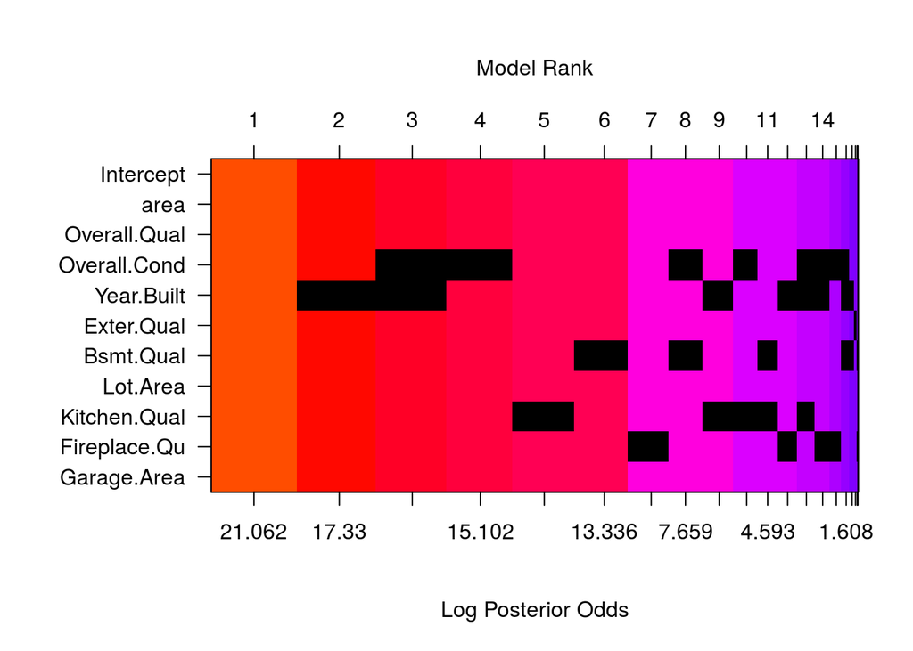

```r
# Model selection using Bayesian Information Criterion (BIC)

houses.BIC = bas.lm(initial.model,
                    prior = "BIC",
                    modelprior = uniform(),
                    data = df.train)

image (houses.BIC, rotate = FALSE)
```

What we see from the analysis is, that all three model selection methods end up with the same result. The initial model provides p-values, which indicate significance for all chosen features. It isn’t really surprising that all approaches came to the same conclusion. I chose features, which I personally would rely on, if I needed to select a house. But anyway, even if all features are relevant, doesn’t per se mean that the model as such is good. The chosen features were intuitively chosen and are all important.

### 2.2.3 Section 2.3 Initial Model Residuals

One way to assess the performance of a model is to examine the model’s residuals. Below, you’ll find a residual plot as well as the applied regression line, which indicates the linearity of the data.

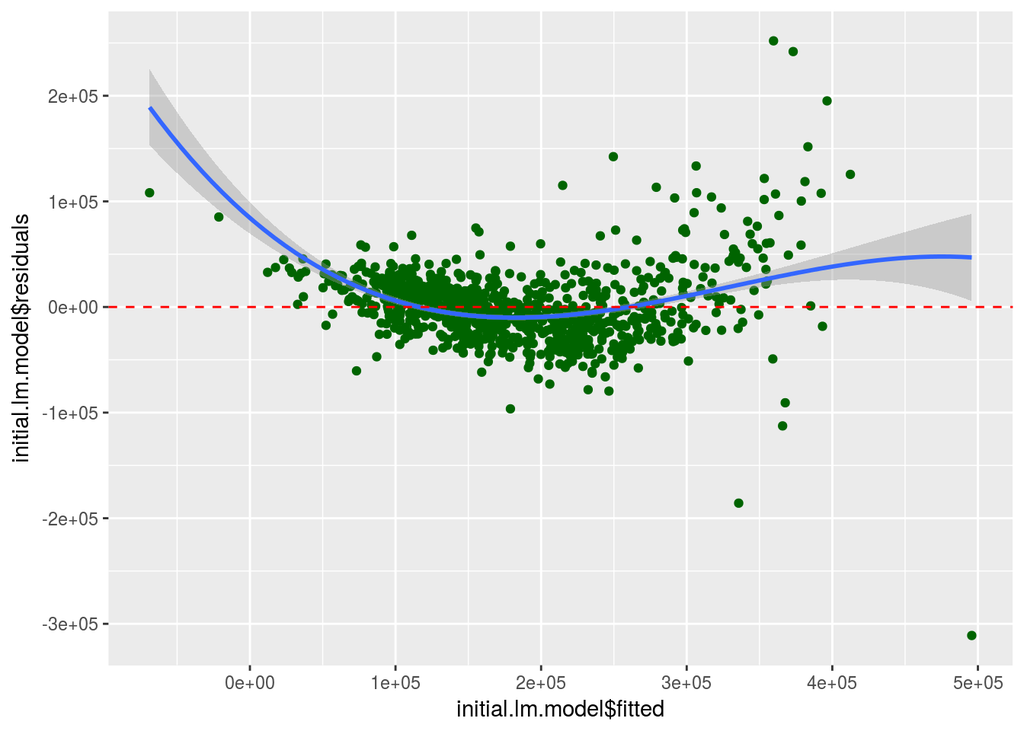

```r
ggplot(data = NULL, aes(x = initial.lm.model$fitted, y = initial.lm.model$residuals)) +
  geom_point(col = 'darkgreen') +
  geom_smooth(method = "lm", formula = y ~ splines::bs(x, 3), se = TRUE) +
  geom_hline(yintercept = 0, linetype = 'dashed', color = 'red')
```

### 2.2.4 Section 2.4 Initial Model RMSE

We will now calculate the Root Mean Squared Error based on the model output.

When we fit a linear regression to a specific data set, many problems may occur. Most common among those are the following: 1) Non linearity of the response - predictor 2) Correlation of error terms 3) Non constant variance of error terms 4) Outliners 5) High leverage point 6) Collinearity

Let’s run an initial analysis by verifying outliners and their impact on the adjusted R2 and RMSE. I’ll investigate the impact on adjusted R2 and RMSE by applying a log transformation on the response variable as well.

```r
predicted <- predict(initial.lm.model, df.train)

RMSE.w_outliner <- rmse(df.train$price, predicted)
adj.r.squared.w_outliner <- summary(initial.lm.model)$adj.r.squared

# Initial Model selection log(price)

formula.log <- as.formula(log(price) ~ area + Overall.Qual + Overall.Cond +
                            Kitchen.Qual + Year.Built + Bsmt.Qual + Exter.Qual +
                            Garage.Area + Lot.Area + Fireplace.Qu)

initial.lm.model.log <- lm(formula.log , data = df.train)
adj.r.squared.log.w_outliner <- summary(initial.lm.model.log)$adj.r.squared

predicted.log <- predict(initial.lm.model.log, df.train)
RMSE.log.w_outliner <- rmse(df.train$price, exp(predicted.log))

# This part verifies the impact of the most severe outliners.
# So we check for outliners. We remove the outliner and re run model
# Afterwards we compare the RMSE and adjusted R Squared.

df.train <- df.train.NoOutliner

# re run model

initial.lm.model <- lm(initial.model , data = df.train)
adj.r.squared.wo_outliner <- summary(initial.lm.model)$adj.r.squared

predicted <- predict(initial.lm.model, df.train)
RMSE.wo_outliner <- rmse(df.train$price, predicted)

# Initial Model selection log(price)

initial.lm.model.log <- lm(formula.log , data = df.train)
adj.r.squared.log.wo_outliner <- summary(initial.lm.model.log)$adj.r.squared

predicted.log <- predict(initial.lm.model.log, df.train)
RMSE.log.wo_outliner <- rmse(df.train$price, exp(predicted.log))

with_outliner <- c(adj.r.squared.w_outliner, RMSE.w_outliner)
without_outliner <- c(adj.r.squared.wo_outliner, RMSE.wo_outliner)
log.with_outliner <- c(adj.r.squared.log.w_outliner, RMSE.log.w_outliner)
log.without_outliner <- c(adj.r.squared.log.wo_outliner, RMSE.log.wo_outliner)
R_Squared_RMSE <- data.frame(rbind(with_outliner, without_outliner, log.with_outliner, log.without_outliner))

colnames(R_Squared_RMSE) <- c('adj_R_Squared', 'RMSE')

kable(R_Squared_RMSE[1:2], caption = 'adjusted R-Squared and RMSE')
```

adjusted R-Squared and RMSE

|  | adj_R_Squared | RMSE |
| --- | --- | --- |
| with_outliner | 0.8156869 | 34971.32 |
| without_outliner | 0.8308574 | 33463.30 |
| log.with_outliner | 0.8518337 | 34871.86 |
| log.without_outliner | 0.8774398 | 28026.33 |

Comparing the adjusted R2 as well as the RMSE as a quality measure, indicate that removing outliners or the transformation of features shows an improvement of the model. The Error of predicting housing prices can be reduced from **34’971.32** Dollars down to **28’026.33** Dollars. But, in this case we used the training data to predict housing prices and not the test-, or validation data.

### 2.2.5 Section 2.5 Overfitting

The process of building a model generally involves starting with an initial model, identifying its shortcomings, and adapting the model accordingly. This process may be repeated several times until the model fits the data reasonably well. However, the model may do well on training data but perform poorly out-of-sample (meaning, on a dataset other than the original training data) because the model is overly-tuned to specifically fit the training data. This is called overfitting. To determine whether overfitting is occurring on our model, we will compare the performance of our model on both in-sample and out-of-sample data sets.

**Remark:** To overcome Overfitting we might also apply a regularization term (L1 or L2) via LASSO or a Ridge regression. This proofed to be helpful and is even easier to apply then getting additional training data or optimizing our model. Regularization allows to play around with a Lambda term to overcome high bias or variance.

```r
df.train <- df.train.NoOutliner

initial.model  <- as.formula(price ~ area + Overall.Qual +
                               Overall.Cond + Year.Built +
                               Exter.Qual +  Bsmt.Qual +
                               Lot.Area + Kitchen.Qual +
                               Fireplace.Qu + Garage.Area)

initial.lm.model <- lm(initial.model , data = df.train)

predicted.train <- predict(initial.lm.model, df.train)
RMSE.train <- sqrt( mean((df.train$price - predicted.train)^2))

predicted.test <- predict(initial.lm.model, df.test)
RMSE.test <- sqrt( mean((df.test$price - predicted.test)^2))

# log transform feature area
initial.model.log  <- as.formula(log(price) ~ log(area) +
                                   Overall.Cond + Overall.Qual +
                                   Year.Built + Exter.Qual +  Bsmt.Qual +
                                   Lot.Area + Kitchen.Qual +
                                   Fireplace.Qu + Garage.Area)

initial.lm.model.log <- lm(initial.model.log , data = df.train)

predicted.train <- predict(initial.lm.model.log, df.train)
RMSE.train.log <- sqrt( mean((df.train$price - exp(predicted.train))^2))

predicted.test <- predict(initial.lm.model.log, df.test)
RMSE.test.log <- sqrt( mean((df.test$price - exp(predicted.test))^2))

Initial.Model <- c(RMSE.train, RMSE.test)
Initial.Model.log <- c(RMSE.train.log, RMSE.test.log)

RMSE.Comp <-data.frame( rbind(Initial.Model, Initial.Model.log))
colnames(RMSE.Comp) <- c('RMSE on train', 'RMSE on test')

kable(RMSE.Comp[1:2], caption = 'RMSE on training and test data')
```

RMSE on training and test data

|  | RMSE on train | RMSE on test |
| --- | --- | --- |
| Initial.Model | 33463.30 | 31238.93 |
| Initial.Model.log | 28638.67 | 26023.57 |

The initial model shows a difference between prediction with training data vs. prediction with test data. The model responds pretty well with the test data. This implies that there is no overfitting of the model. Applying some feature transformation also added some advantage as shown in the table.